# Perception des distances exocentriques - Analyse

# Analyse générale

### Boite à moustache triées par médiane croissante de l’ensemble des données des participants.

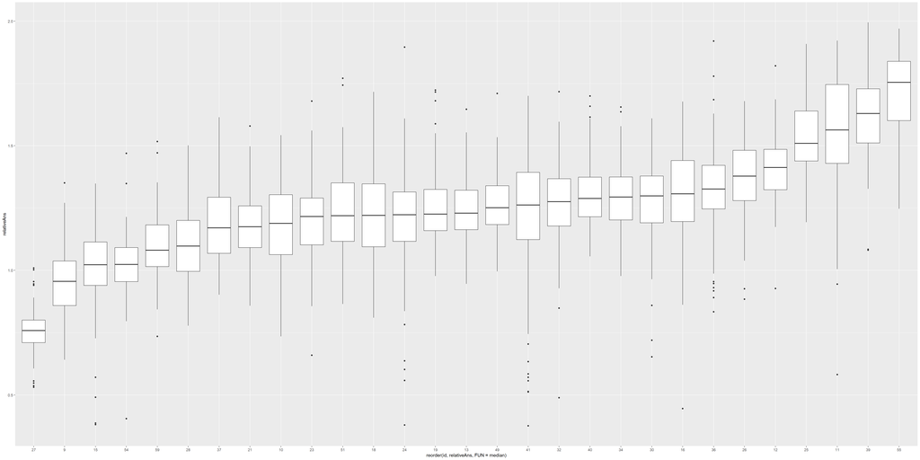

27 est visiblement à part. Il sera supprimé pour la suite de l’analyse.

# Données individuelles - Détails

### Régression linéaire des réponses individuelles, en fonction de la distance entre les sphères.

[figure not shown]

### Anova multivariée avec e traité comme donnée continue

```
## Anova Table (Type 3 tests)
##
## Response: relativeAns
##   Effect            df  MSE         F pes p.value
## 1      e   2.62, 65.43 0.04      1.96 .07     .14
## 2   type   2.15, 53.67 0.03 14.32 *** .36  <.0001
## 3 e:type 11.66, 291.44 0.01    1.61 + .06     .09
## ---
## Signif. codes:  0 '***' 0.001 '**' 0.01 '*' 0.05 '+' 0.1 ' ' 1
##
## Sphericity correction method: GG
```

Il n’y a pas de tendance linéaire visible sur les données individuelles et ‘e’ n’est pas un facteur significatif de l’Anova. Les données de chaque groupe sont moyennées sur l’ensemble des distances dans la suite.

11 et 41 présentent de nombreux outliers et certains groupes manque de points (suite au filtrage en première partie). Ils seront supprimés pour la suite de l’analyse.

# Données moyennées

### Boite à moustaches des données individuelles par groupe

[figure not shown]

### Agregat des données précédentes, triées par moyenne

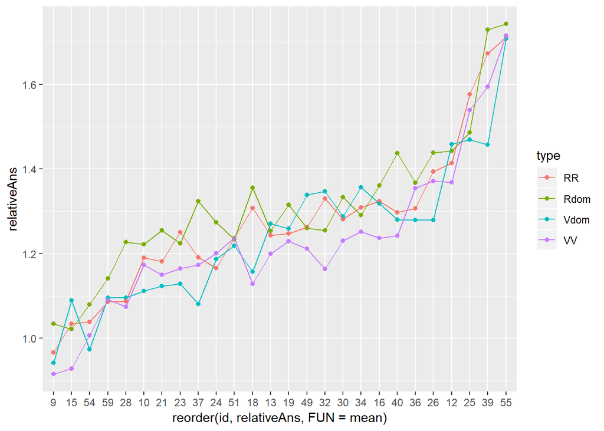

C’est très moche, donc on va travailler en relatif.

### Résultats “relatifs” en prenant le cas RR comme référence

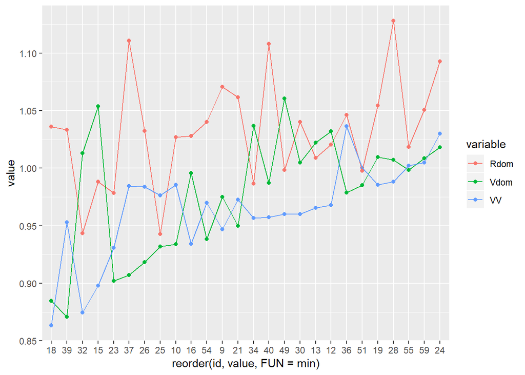

# Analyse finale (après filtrage et avec les données relatives)

Ces résultats sont les mêmes que ceux présentés dans le papier mais rectifiés en supprimants les participants mentionnées ci-avant. (Ca ne change rien.)

```
##   variable  N     value         sd          se         ci  name
## 1     Rdom 26 1.0324746 0.04661771 0.009142484 0.01882930 value
## 2     Vdom 26 0.9778752 0.05255703 0.010307282 0.02122824 value
## 3       VV 26 0.9649754 0.04083647 0.008008691 0.01649421 value
```

```
## Anova Table (Type 3 tests)
##
## Response: value
##     Effect          df  MSE         F pes p.value
## 1 variable 1.66, 41.44 0.00 17.13 *** .41  <.0001
## ---
## Signif. codes:  0 '***' 0.001 '**' 0.01 '*' 0.05 '+' 0.1 ' ' 1
##
## Sphericity correction method: GG
```

```
##   variable  N     value         sd          se         ci  name
## 1     Rdom 26 1.0324746 0.04661771 0.009142484 0.01882930 value
## 2     Vdom 26 0.9778752 0.05255703 0.010307282 0.02122824 value
## 3       VV 26 0.9649754 0.04083647 0.008008691 0.01649421 value
```

```
##
##   Simultaneous Tests for General Linear Hypotheses
##
## Linear Hypotheses:
##                  Estimate Std. Error t value Pr(>|t|)
## Rdom - Vdom == 0  0.05460    0.01224   4.460  0.00014 ***
## Rdom - VV == 0    0.06750    0.01224   5.514  3.7e-06 ***
## Vdom - VV == 0    0.01290    0.01224   1.054  0.89123
## ---
## Signif. codes:  0 '***' 0.001 '**' 0.01 '*' 0.05 '.' 0.1 ' ' 1
## (Adjusted p values reported -- bonferroni method)
```

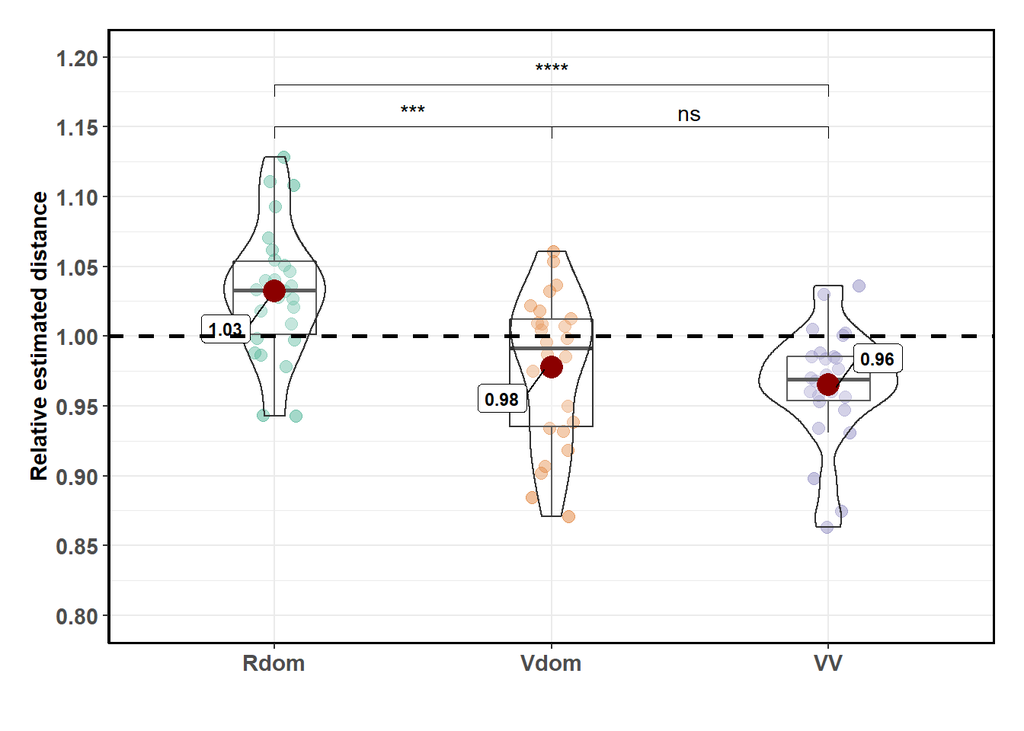

Remarque : les étoiles sont calulées sans la correction de Bonferroni

Au final, on retrouve que Rdom est significativement différent de Vdom et de VV. Alors que Vdom et VV ne sont pas différents.